# Annotating and prioritizing genetic variants for single cell RNA sequencing

This vignette demonstrates how Yano can annotate genetic variants using public databases and assist users in interpreting the functional impact of these variants. The pathogenic mutations in single cells may help understand gene function or lineage tracing, but they are not relevant to the allele specific expression. So this vignette reuses the data but is independent from allele specific gene expression from scRNA-seq.

## 1. Predict the consequence of genetic variants

Load the object which was generated from allele specific gene expression from scRNA-seq. In that case, we used annoVAR to annotate the gene and approximate gene region type for the variants. In this section, we will go further, to predict the consequence of genetic variants. Note that, different from genetic annotation at DNA level, strand information is also considered here, so antisense terms will also be generated.

The predicted consequences were derived from transcript annotations. However, GENCODE annotations, generated as part of the ENCODE project, contain numerous truncated transcript records that are not fully consistent with the reference genome, which can introduce bias when predicting amino acid changes. For gene expression analysis, such as scRNA-seq, it is more common to use GENCODE, considering its good coverage. But for clinical research, validated annotations like RefSeq are preferred for genetic variant annotation. In this analysis, RefSeq annotations were downloaded from the UCSC server to provide more accurate and reliable predictions. Furthermore, the human genome reference is also needed for the prediction.

```bash
wget -c https://hgdownload.soe.ucsc.edu/goldenPath/archive/hg38/ncbiRefSeq/110/hg38.110.ncbiRefSeq.gtf.gz
wget -c https://ftp.ebi.ac.uk/pub/databases/gencode/Gencode_human/release_32/GRCh38.p13.genome.fa.gz
unzip GRCh38.p13.genome.fa.gz

# FASTA need to be indexed
samtools faidx GRCh38.p13.genome.fa
```

```r
require(Seurat)
```

```r
require(ggplot2)
require(dplyr)
require(Yano)
obj <- readRDS("glioblastoma5k.rds")

gtf <- gtf2db("hg38.110.ncbiRefSeq.gtf.gz")
```

```
## [2026-06-10 12:54:55] GTF loading..
## [2026-06-10 12:55:11] Load 66991 genes.
## [2026-06-10 12:55:11] Load time : 15.683 sec
```

```r
DefaultAssay(obj) <- "var"
obj <- annoVAR(obj, gtf = gtf, fasta = "./GRCh38.p13.genome.fa")
```

[output not shown]

```r
obj[['var']][[]] -> df
head(df)
```

```
##                   chr  start ref alt strand         locus gene_name type
## chr1:633192G=/+  chr1 633192   G   G      + chr1:633192/+  MTCO2P12 utr5
## chr1:634337T>C/+ chr1 634337   T   C      + chr1:634337/+  MTATP6P1 utr5
## chr1:853876T>C/+ chr1 853876   T   C      + chr1:853876/+ LINC01128 utr5
## chr1:944296G>A/- chr1 944296   G   A      - chr1:944296/-     NOC2L utr3
## chr1:944296G>A/+ chr1 944296   G   A      + chr1:944296/+    SAMD11 utr5
## chr1:944307T>C/+ chr1 944307   T   C      + chr1:944307/+    SAMD11 utr5
##                  moransi.pval       moransi autocorr.variable locus.D locus.t
## chr1:633192G=/+  1.166169e-02  0.0092264381             FALSE      NA      NA
## chr1:634337T>C/+ 4.983857e-01 -0.0004829586             FALSE      NA      NA
## chr1:853876T>C/+ 2.989452e-05  0.0173380133              TRUE      NA      NA
## chr1:944296G>A/- 6.241826e-01 -0.0019072667             FALSE      NA      NA
## chr1:944296G>A/+ 1.956662e-05  0.0174094379              TRUE      NA      NA
## chr1:944307T>C/+ 8.943382e-06  0.0182656894              TRUE      NA      NA
##                  locus.pval locus.padj    consequence
## chr1:633192G=/+          NA         NA            ref
## chr1:634337T>C/+         NA         NA noncoding_exon
## chr1:853876T>C/+         NA         NA noncoding_exon
## chr1:944296G>A/-         NA         NA           utr3
## chr1:944296G>A/+         NA         NA           utr3
## chr1:944307T>C/+         NA         NA           utr3
```

```r
table(df$consequence)
```

```
##
## antisense_downstream_1K          antisense_exon        antisense_intron
##                      70                     565                    4213
##   antisense_upstream_1K           downstream_1K   frameshift_truncation
##                     192                     486                       2
##              intergenic                  intron                missense
##                    2820                   11633                     656
##          noncoding_exon        noncoding_intron noncoding_splice_region
##                     911                     865                       1
##                     ref         splice_acceptor            splice_donor
##                   11575                       3                       3
##           splice_region            splice_sites              start_loss
##                      21                      12                       1
##          start_retained             stop_gained              synonymous
##                       1                       6                     808
##             upstream_1K                    utr3                    utr5
##                     174                    4991                     620
```

```r
subset(df, consequence %in% "stop_gained")
```

```
##                       chr     start ref alt strand            locus gene_name
## chr11:62602409G>A/- chr11  62602409   G   A      - chr11:62602409/-      EML3
## chr21:21480040G>A/+ chr21  21480040   G   A      + chr21:21480040/+     NCAM2
## chr3:53865249C>T/+   chr3  53865249   C   T      +  chr3:53865249/+    IL17RB
## chr5:140557175G>T/-  chr5 140557175   G   T      - chr5:140557175/-      SRA1
## chr7:55473014G>A/-   chr7  55473014   G   A      -  chr7:55473014/-     VOPP1
## chr7:74732529C>T/+   chr7  74732529   C   T      +  chr7:74732529/+     GTF2I
##                       type moransi.pval       moransi autocorr.variable
## chr11:62602409G>A/-   exon 5.256860e-02  0.0067094190             FALSE
## chr21:21480040G>A/+ intron 5.411995e-01 -0.0009469328             FALSE
## chr3:53865249C>T/+    exon 3.922015e-01  0.0006724034             FALSE
## chr5:140557175G>T/-   exon 1.711549e-01  0.0036300710             FALSE
## chr7:55473014G>A/-    exon 1.044624e-05  0.0184269383              TRUE
## chr7:74732529C>T/+    exon 7.364633e-03  0.0098886180              TRUE
##                       locus.D   locus.t locus.pval locus.padj consequence
## chr11:62602409G>A/-        NA        NA         NA         NA stop_gained
## chr21:21480040G>A/+        NA        NA         NA         NA stop_gained
## chr3:53865249C>T/+         NA        NA         NA         NA stop_gained
## chr5:140557175G>T/-        NA        NA         NA         NA stop_gained
## chr7:55473014G>A/-         NA        NA         NA         NA stop_gained
## chr7:74732529C>T/+  0.1840882 -2.215475 0.01450941  0.4377365 stop_gained
```

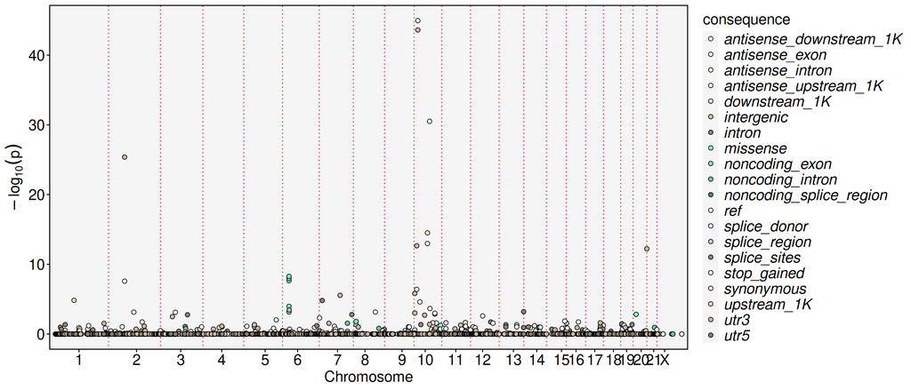

```r
sel.chrs <- c(1:21, "X")
FbtPlot(obj, val = "locus.padj", remove.chr = TRUE, sel.chrs = sel.chrs, col.by = "consequence", pt.size = 2)
```

Map the consequence of genetic variants to Manhattan plot just for visualization but the p-value bears no relation to the consequence.

## 2. Annotate genetic variants with publish databases

Another key advancement in genetic variant studies is the ability to perform annotation using genotype-phenotype and allele frequency databases. For demonstration purposes, we use the [ClinVar](https://www.ncbi.nlm.nih.gov/clinvar/) database for annotation in this vignette.

```bash
# download the database in VCF format
wget -c  https://ftp.ncbi.nlm.nih.gov/pub/clinvar/vcf_GRCh38/clinvar.vcf.gz

# remember to index this database, otherwise annoVAR will report an error.
bcftools index clinvar.vcf.gz
```

Let’s take a look at the format of the ClinVar database. As noted, the chromosome names are in the NCBI style, meaning they do not include the “chr” prefix. Therefore, we need to generate a new column with chromosome names formatted for annotation.

```bash
bcftools view clinvar.vcf.gz| grep -v "^#"| head
```

```
## 1    66926   3385321 AG  A   .   .   ALLELEID=3544463;CLNDISDB=Human_Phenotype_Ontology:HP:0000547,MONDO:MONDO:0019200,MeSH:D012174,MedGen:C0035334,OMIM:268000,OMIM:PS268000,Orphanet:791;CLNDN=Retinitis_pigmentosa;CLNHGVS=NC_000001.11:g.66927del;CLNREVSTAT=criteria_provided,_single_submitter;CLNS…
## 1    69134   2205837 A   G   .   .   ALLELEID=2193183;CLNDISDB=MedGen:CN169374;CLNDN=not_specified;CLNHGVS=NC_000001.11:g.69134A>G;CLNREVSTAT=criteria_provided,_single_submitter;CLNSIG=Likely_benign;CLNSIGSCV=SCV003526545;CLNVC=single_nucleotide_variant;CLNVCSO=SO:0001483;CLNVI=ClinGen:CA502008;G…
## 1    69314   3205580 T   G   .   .   ALLELEID=3374047;CLNDISDB=MedGen:CN169374;CLNDN=not_specified;CLNHGVS=NC_000001.11:g.69314T>G;CLNREVSTAT=criteria_provided,_single_submitter;CLNSIG=Uncertain_significance;CLNSIGSCV=SCV004995495;CLNVC=single_nucleotide_variant;CLNVCSO=SO:0001483;CLNVI=ClinGen:C…
## 1    69423   3205581 G   A   .   .   ALLELEID=3374048;CLNDISDB=MedGen:CN169374;CLNDN=not_specified;CLNHGVS=NC_000001.11:g.69423G>A;CLNREVSTAT=criteria_provided,_single_submitter;CLNSIG=Uncertain_significance;CLNSIGSCV=SCV004995496;CLNVC=single_nucleotide_variant;CLNVCSO=SO:0001483;CLNVI=ClinGen:C…
## 1    69581   2252161 C   G   .   .   ALLELEID=2238986;CLNDISDB=MedGen:CN169374;CLNDN=not_specified;CLNHGVS=NC_000001.11:g.69581C>G;CLNREVSTAT=criteria_provided,_single_submitter;CLNSIG=Uncertain_significance;CLNSIGSCV=SCV003584698;CLNVC=single_nucleotide_variant;CLNVCSO=SO:0001483;CLNVI=ClinGen:C…
## 1    69682   2396347 G   A   .   .   ALLELEID=2386655;CLNDISDB=MedGen:CN169374;CLNDN=not_specified;CLNHGVS=NC_000001.11:g.69682G>A;CLNREVSTAT=criteria_provided,_single_submitter;CLNSIG=Uncertain_significance;CLNSIGSCV=SCV003739621;CLNVC=single_nucleotide_variant;CLNVCSO=SO:0001483;CLNVI=ClinGen:C…
## 1    69731   3205582 T   C   .   .   ALLELEID=3374049;CLNDISDB=MedGen:CN169374;CLNDN=not_specified;CLNHGVS=NC_000001.11:g.69731T>C;CLNREVSTAT=criteria_provided,_single_submitter;CLNSIG=Uncertain_significance;CLNSIGSCV=SCV004995497;CLNVC=single_nucleotide_variant;CLNVCSO=SO:0001483;CLNVI=ClinGen:C…
## 1    69769   2288999 T   C   .   .   ALLELEID=2278803;CLNDISDB=MedGen:CN169374;CLNDN=not_specified;CLNHGVS=NC_000001.11:g.69769T>C;CLNREVSTAT=criteria_provided,_single_submitter;CLNSIG=Uncertain_significance;CLNSIGSCV=SCV003620560;CLNVC=single_nucleotide_variant;CLNVCSO=SO:0001483;CLNVI=ClinGen:C…
## 1    69995   2351346 G   C   .   .   ALLELEID=2333177;CLNDISDB=MedGen:CN169374;CLNDN=not_specified;CLNHGVS=NC_000001.11:g.69995G>C;CLNREVSTAT=criteria_provided,_single_submitter;CLNSIG=Uncertain_significance;CLNSIGSCV=SCV003688488;CLNVC=single_nucleotide_variant;CLNVCSO=SO:0001483;CLNVI=ClinGen:C…
## 1    924518  3388928 G   C   .   .   ALLELEID=3548054;CLNDISDB=MedGen:C3661900;CLNDN=not_provided;CLNHGVS=NC_000001.11:g.924518G>C;CLNREVSTAT=criteria_provided,_single_submitter;CLNSIG=Likely_benign;CLNSIGSCV=SCV005435063;CLNVC=single_nucleotide_variant;CLNVCSO=SO:0001483;GENEINFO=SAMD11:148398|L…
```

We need to create new chromosome names that are compatible with the NCBI database format, because chromosome names in the ClinVar database look like ‘1’, ‘2’.

```r
obj[['var']][['chr0']] <- gsub("chr(.*)","\\1", obj[['var']][[]]$chr)
obj[['var']][[]] %>% head
```

```
##                   chr  start ref alt strand         locus gene_name type
## chr1:633192G=/+  chr1 633192   G   G      + chr1:633192/+  MTCO2P12 utr5
## chr1:634337T>C/+ chr1 634337   T   C      + chr1:634337/+  MTATP6P1 utr5
## chr1:853876T>C/+ chr1 853876   T   C      + chr1:853876/+ LINC01128 utr5
## chr1:944296G>A/- chr1 944296   G   A      - chr1:944296/-     NOC2L utr3
## chr1:944296G>A/+ chr1 944296   G   A      + chr1:944296/+    SAMD11 utr5
## chr1:944307T>C/+ chr1 944307   T   C      + chr1:944307/+    SAMD11 utr5
##                  moransi.pval       moransi autocorr.variable locus.D locus.t
## chr1:633192G=/+  1.166169e-02  0.0092264381             FALSE      NA      NA
## chr1:634337T>C/+ 4.983857e-01 -0.0004829586             FALSE      NA      NA
## chr1:853876T>C/+ 2.989452e-05  0.0173380133              TRUE      NA      NA
## chr1:944296G>A/- 6.241826e-01 -0.0019072667             FALSE      NA      NA
## chr1:944296G>A/+ 1.956662e-05  0.0174094379              TRUE      NA      NA
## chr1:944307T>C/+ 8.943382e-06  0.0182656894              TRUE      NA      NA
##                  locus.pval locus.padj    consequence chr0
## chr1:633192G=/+          NA         NA            ref    1
## chr1:634337T>C/+         NA         NA noncoding_exon    1
## chr1:853876T>C/+         NA         NA noncoding_exon    1
## chr1:944296G>A/-         NA         NA           utr3    1
## chr1:944296G>A/+         NA         NA           utr3    1
## chr1:944307T>C/+         NA         NA           utr3    1
```

```r
# here we annotate RS id and clinical signification for variants, to check the VCF header for all possible tags
obj <- annoVAR(obj, vcf = "clinvar.vcf.gz", chr = "chr0", tags = c("RS", "CLNSIG"))

# The RS id and CLNSIG tag now created
obj[['var']][[]] -> df
head(df)
```

```
##                   chr  start ref alt strand         locus gene_name type
## chr1:633192G=/+  chr1 633192   G   G      + chr1:633192/+  MTCO2P12 utr5
## chr1:634337T>C/+ chr1 634337   T   C      + chr1:634337/+  MTATP6P1 utr5
## chr1:853876T>C/+ chr1 853876   T   C      + chr1:853876/+ LINC01128 utr5
## chr1:944296G>A/- chr1 944296   G   A      - chr1:944296/-     NOC2L utr3
## chr1:944296G>A/+ chr1 944296   G   A      + chr1:944296/+    SAMD11 utr5
## chr1:944307T>C/+ chr1 944307   T   C      + chr1:944307/+    SAMD11 utr5
##                  moransi.pval       moransi autocorr.variable locus.D locus.t
## chr1:633192G=/+  1.166169e-02  0.0092264381             FALSE      NA      NA
## chr1:634337T>C/+ 4.983857e-01 -0.0004829586             FALSE      NA      NA
## chr1:853876T>C/+ 2.989452e-05  0.0173380133              TRUE      NA      NA
## chr1:944296G>A/- 6.241826e-01 -0.0019072667             FALSE      NA      NA
## chr1:944296G>A/+ 1.956662e-05  0.0174094379              TRUE      NA      NA
## chr1:944307T>C/+ 8.943382e-06  0.0182656894              TRUE      NA      NA
##                  locus.pval locus.padj    consequence chr0   RS CLNSIG
## chr1:633192G=/+          NA         NA            ref    1 <NA>   <NA>
## chr1:634337T>C/+         NA         NA noncoding_exon    1 <NA>   <NA>
## chr1:853876T>C/+         NA         NA noncoding_exon    1 <NA>   <NA>
## chr1:944296G>A/-         NA         NA           utr3    1 <NA>   <NA>
## chr1:944296G>A/+         NA         NA           utr3    1 <NA>   <NA>
## chr1:944307T>C/+         NA         NA           utr3    1 <NA>   <NA>
```

```r
# We note that there are several pathogenic variants detected
table(df[['CLNSIG']])
```

```
##
##                                              association
##                                                        8
##                                                   Benign
##                                                     1710
##                                     Benign/Likely_benign
##                                                       44
##                                       Benign|risk_factor
##                                                        1
##             Conflicting_classifications_of_pathogenicity
##                                                       10
## Conflicting_classifications_of_pathogenicity|risk_factor
##                                                        3
##                                            drug_response
##                                                        1
##                                            Likely_benign
##                                                       51
##                                        Likely_pathogenic
##                                                        1
##                 no_classification_for_the_single_variant
##                                                       22
##                                             not_provided
##                                                        1
##                                                    other
##                                                       10
##                                               Pathogenic
##                                                        1
##                             Pathogenic/Likely_pathogenic
##                                                        3
##                                   Pathogenic|risk_factor
##                                                        1
##                                              risk_factor
##                                                        6
##                                   Uncertain_significance
##                                                       31
```

```r
df %>% filter(CLNSIG %in% c('Pathogenic', 'Pathogenic/Likely_pathogenic', 'Pathogenic|risk_factor'))
```

```
##                       chr     start ref alt strand            locus gene_name
## chr1:97450058C=/-    chr1  97450058   C   C      -  chr1:97450058/-      DPYD
## chr1:196690107C=/+   chr1 196690107   C   C      + chr1:196690107/+       CFH
## chr13:50945445G=/+  chr13  50945445   G   G      + chr13:50945445/+  RNASEH2B
## chr13:50945445G>A/+ chr13  50945445   G   A      + chr13:50945445/+  RNASEH2B
## chr15:92992967C=/+  chr15  92992967   C   C      + chr15:92992967/+      CHD2
##                           type  moransi.pval      moransi autocorr.variable
## chr1:97450058C=/-       intron  6.067765e-01 -0.001651815             FALSE
## chr1:196690107C=/+  multigenes 7.391637e-156  0.112274939              TRUE
## chr13:50945445G=/+        exon  4.246920e-02  0.007144311             FALSE
## chr13:50945445G>A/+       exon  3.784209e-10  0.026831972              TRUE
## chr15:92992967C=/+        exon  6.935523e-01 -0.002685458             FALSE
##                       locus.D   locus.t locus.pval locus.padj consequence chr0
## chr1:97450058C=/-          NA        NA         NA         NA         ref    1
## chr1:196690107C=/+  0.1100850 1.4388352  0.9233243          1         ref    1
## chr13:50945445G=/+         NA        NA         NA         NA         ref   13
## chr13:50945445G>A/+ 0.1403593 0.2441517  0.5961907          1    missense   13
## chr15:92992967C=/+         NA        NA         NA         NA         ref   15
##                           RS                       CLNSIG
## chr1:97450058C=/-    3918290 Pathogenic/Likely_pathogenic
## chr1:196690107C=/+   1061170       Pathogenic|risk_factor
## chr13:50945445G=/+  75184679 Pathogenic/Likely_pathogenic
## chr13:50945445G>A/+ 75184679 Pathogenic/Likely_pathogenic
## chr15:92992967C=/+   2272457                   Pathogenic
```

In the selected SNVs, we found some reference alleles are highlighted, such as chr15:92992967C=/+. These reference alleles are more likely to be benign alleles. Let’s query the original record in the ClinVar database to check what the exact situation is.

```bash
bcftools view clinvar.vcf.gz 15:92992967-92992967
```

[output not shown]

[output cut: 25 more lines]

```
## ##contig=<ID=21>
## ##contig=<ID=22>
## ##contig=<ID=X>
## ##contig=<ID=Y>
## ##contig=<ID=MT>
## ##contig=<ID=NT_113889.1>
## ##contig=<ID=NT_187633.1>
## ##contig=<ID=NT_187661.1>
## ##contig=<ID=NT_187693.1>
## ##contig=<ID=NW_009646201.1>
## ##bcftools_viewVersion=1.19+htslib-1.19
## ##bcftools_viewCommand=view clinvar.vcf.gz 15:92992967-92992967; Date=Wed Jun 10 12:55:17 2026
## #CHROM   POS ID  REF ALT QUAL    FILTER  INFO
## 15   92992967    633515  C   G   .   .   ALLELEID=621980;CLNDISDB=MedGen:CN517202;CLNDN=not_provided;CLNHGVS=NC_000015.10:g.92992967C>G;CLNREVSTAT=criteria_provided,_single_submitter;CLNSIG=Pathogenic;CLNSIGSCV=SCV000920484;CLNVC=single_nucleotide_variant;CLNVCSO=SO:0001483;CLNVI=ClinGen:CA393896…
## 15   92992967    257709  C   T   .   .   AF_ESP=0.2485;AF_EXAC=0.22658;AF_TGP=0.19349;ALLELEID=255446;CLNDISDB=MeSH:D030342,MedGen:C0950123|MONDO:MONDO:0014150,MedGen:C3809278,OMIM:615369,Orphanet:1942,Orphanet:2382|MedGen:C3661900|MedGen:CN169374;CLNDN=Inborn_genetic_diseases|Developmental_and_e…
```

Unfortunately, many databases distributed in VCF format may contain inconsistently formatted tags. Apart from manually updating these databases or filtering reference alleles afterward, there is no straightforward solution to this issue.

In addition, the RS tag is annotated, and we can refer to the NCBI SNP database for more information. For example, the mutation chr13:50945445G>A/+ at RS 75184679 can be found at the following link: https://www.ncbi.nlm.nih.gov/snp/rs75184679. This mutation is associated with conditions such as “Abnormality of the nervous system” and other diseases.

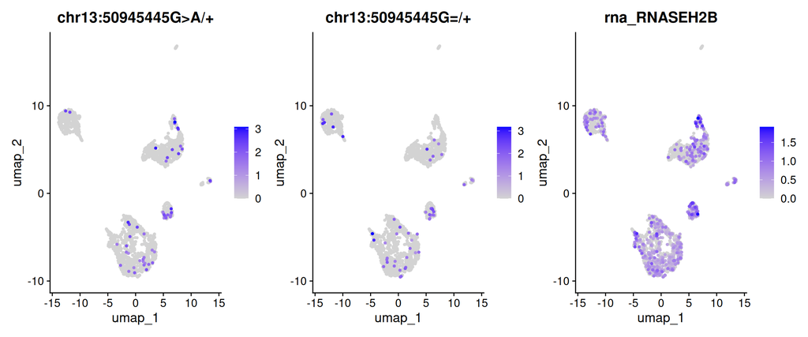

```r
FeaturePlot(obj, features = c("chr13:50945445G>A/+", "chr13:50945445G=/+", "RNASEH2B"), order = TRUE, ncol=3)
```

Note that not all reads from this gene cover the SNV, which results in the SNV expression being sparser compared to the overall gene expression. So it is recommended to visualize both alleles for the same location together.

```r
Command(obj)
```

```
##  [1] "NormalizeData.RNA"        "FindVariableFeatures.RNA"
##  [3] "ScaleData.RNA"            "RunPCA.RNA"
##  [5] "FindNeighbors.RNA.pca"    "FindClusters"
##  [7] "RunUMAP.RNA.pca"          "NormalizeData.var"
##  [9] "ParseVarName.var"         "RunAutoCorr.var.pca"
## [11] "SetAutoCorrFeatures.var"  "RunSDT.var"
## [13] "annoVAR.var"
```